# CSE204 - Introduction to Machine Learning - Lab Session 5 - Exam

[CSE204-2021](https://moodle.polytechnique.fr/enrol/index.php?id=12838) Lab session #05 - Lab Exam

Théo Lacombe - Adrien Ehrhardt

## Overall presentation

This lab is composed of 3 exercises, granting up to 6, 7.5 and 5.5 points, and 2 additional exercises (2 pts each - the final grade is over 20, so there are bonus points).

These exercises are independant.

There are examples of automatic tests that are run against your code. **They are not exhaustive nor sufficient** (we will run other - hidden - tests), **but they are necessary**: they have to pass, otherwise you can be sure *not* to get the points.

You **cannot** use past lab sessions' solutions, nor Google anything. The exam is open book w.r.t. the lectures. Some help and hints are provided for each question (e.g. which function to use and how), and you can also use the `help(...)` function.

- **Do not** delete any pre-existing cell (you can create and delete your own cells for testing).
- **Do not** change the type (Markdown / Code / ...) of any pre-existing cell.
- Run the notebook with the **CSE204** kernel - if you didn't install it beforehand (come on, it's the $5^{th}$ lab!), proceed at your own risk.
- **Do not** rename the file when uploading your work on Moodle.
- **Do not** edit the notebook's or a cell's metadata.

## Imports

```python
%matplotlib inline
import numpy as np
import pandas as pd
import sklearn as sk
import matplotlib.pyplot as plt
from mpl_toolkits.mplot3d import Axes3D

from sklearn.neighbors import KNeighborsClassifier
from sklearn.metrics import accuracy_score
from sklearn import datasets
from sklearn import model_selection
```

```python
def gen_d_regression_samples(n_samples: int = 50, p: int = 3,
                             reg_type: str = 'linear', seed: int = 1) -> pd.DataFrame:
    """
    Generate p-dimensional regression samples

    :param int n_samples: number of samples to draw
    :param int p: dimension of the inputs
    :param str reg_type: either linear or polynomial
    :param int seed: random seed
    :return: dataframe with (x_i)_1^p and y
    :rtype: pandas.DataFrame
    """
    np.random.seed(1)
    if reg_type=='linear':
        x = np.random.uniform(low=1.5, high=3, size=(n_samples, p))
        y = np.sum(x, axis=1) + np.random.normal(scale=0.15, size=n_samples)
        df = pd.DataFrame(x, columns=['x' + str(i) for i in range(p)])
        df['y'] = y
    else:
        x = np.random.uniform(low=0, high=1.5, size=(n_samples, p))
        y = np.sum(x, axis=1) + np.sum(x**2, axis=1) + np.random.normal(scale=0.1, size=n_samples)
        df = pd.DataFrame(x, columns=['x' + str(i) for i in range(p)])
        df['y'] = y

    return df
```

# Exercise 1: Linear regression and its extensions

We briefly recall the framework of linear regression.

We suppose data is generated following: $y = f(x) + \epsilon = \theta_0 + \theta_1 x^{(i)}_1 + \dots + \theta_p x^{(i)}_p + \epsilon$ where $\epsilon \sim \mathcal{N}(0, \sigma)$.

Consider observations $\boldsymbol{X} = \left( x^{(1)} \dots x^{(n)} \right)^T$, with $x^{(i)} \in \mathbb{R}^p$, and labels $\boldsymbol{y} = \left( y^{(1)} \dots y^{(n)} \right)^T$. Given an observation $x^{(i)}$, and a vector $\theta = (\theta_0 \dots \theta_p)^T$, we produce an estimation $\hat{y}^{(i)}$ of $y^{(i)}$ of the following form: $$ \hat{y}^{(i)} = \hat{f}(x) = \theta_0 + \theta_1 x^{(i)}_1 + \dots + \theta_p x^{(i)}_p.$$

## Vanilla linear regression

Let's sample some data.

```python
linear_df = gen_d_regression_samples(n_samples=200, p=2)
```

```python
linear_df.head()
```

|  | x0 | x1 | y |
| --- | --- | --- | --- |
| 0 | 2.125533 | 2.580487 | 4.804207 |
| 1 | 1.500172 | 1.953499 | 3.445992 |
| 2 | 1.720134 | 1.638508 | 3.249802 |
| 3 | 1.779390 | 2.018341 | 3.667566 |
| 4 | 2.095151 | 2.308225 | 4.382980 |

**Question 1: (1pt)** Implement a function `pred` which, given an observation `x` of shape `p` and a vector `theta` of shape `p+1`, returns a predicted value `y_hat`, given the mathematical expression above.

*Hint:* Do not forget the constant term $\theta_0$ - hence the different shapes for `x` and `theta` - for example, `1` can be "added" to `x` inside the `pred` function if you wish to use vector / matrix multiplication.

*Python hints* :

- You can use `np.concatenate((A, B))` to concatenate two numpy arrays.
- You can use `np.dot(A,B)`, or equivalently `A.dot(B)` to compute the matrix-matrix (or matrix-vector) $A \cdot B$ product between two numpy arrays `A` and `B`. Equivalently, you can use matrix multiplication with vectors (either `A @ B` or `np.matmul(A, B)`), but beware of the shapes!

```python
def pred(x: np.array, theta: np.array) -> float:
    """
    Implementation of f_hat

    :param numpy.array x: a sample with p features
    :param numpy.array theta: a vector of (p + 1) parameters
    :return: y_hat
    :rtype: float
    """
    ### BEGIN SOLUTION
    # First, we add a bias term (IMPORTANT!) to our data point x, a p-dimensional vector,
    # which also makes its shape p+1.

    # Second, we compute a dot product of the extended x vector with the theta vector, the weights.

    # We return the prediction given by this regression model.
    return np.dot(np.concatenate((np.array([1]), x), 0), theta)
    ### END SOLUTION
```

```python
assert pred(np.array([0]), np.array([0,0])) == 0  # This computes y_hat = 0 + 0 * 0 which should be 0
### BEGIN HIDDEN TESTS
assert pred(np.array([1]), np.array([1,1])) == 2
### END HIDDEN TESTS
```

Recall that all samples are gathered in matrices $\boldsymbol{X}$ and $\boldsymbol{y}$, where $$ \boldsymbol{X} = \begin{pmatrix} x_1^{(1)} & \dots & x_p^{(1)} \\ \vdots & \vdots & \vdots \\ x_1^{(n)} & \dots & x_p^{(n)} \end{pmatrix} \quad \text{and} \quad \boldsymbol{y} = \begin{pmatrix} y^{(1)} \\ \vdots \\ y^{(n)} \end{pmatrix}. $$

We propose a loss function $E(\theta) := \| \boldsymbol{y} - \boldsymbol{X}^T \theta\|^2_2$ which is the sum of squared errors (differences between the true and predicted value for each $x$ in $\boldsymbol{X}$), or equivalently (in vector form) the norm of the vector of each sample's prediction error $y^{(i)} - \hat{y}^{(i)}$.

**Question 2: (1pt)** Implement a function `E` which, given `X, y, theta` computes the error $E(\theta)$ defined above (you can use the `pred` function defined in question 1).

*Python hint:* You can compute the norm of a vector `A` using `np.linalg.norm(A)`.

```python
def E(X: np.array, y: np.array, theta: np.array) -> float:
    """
    Implementation of the error function: sum of squared errors

    :param numpy.array X: design matrix of shape N x p
    :param numpy.array y: response values of shape N
    :param numpy.array theta: coefficient of shape (p+1)
    :return: evaluation of the error function
    :rtype: float
    """
    ### BEGIN SOLUTION
    # First, we construct a list of predictions by calling pred function on the x data point with theta weights vector.
    # Then, we subtract y, the correct output vector, and compute the distance using np.linalg.norm
    # We return squared distance.
    return np.linalg.norm([pred(x, theta) for x in X] - y) ** 2
    ### END SOLUTION
```

```python
# Test for a particular value of E
assert int(E(linear_df[['x0', 'x1']].to_numpy(), linear_df['y'], np.array([0,0,0]))) == 4180
### BEGIN HIDDEN TESTS
assert int(E(linear_df[['x0', 'x1']].to_numpy(), linear_df['y'], np.array([1,1,1]))) == 205
### END HIDDEN TESTS
```

We want to find an optimal vector $\theta^*$ so that the loss made by using $\hat{y}^{(i)}$ to approximate $y^{(i)}$ is small. With vector notations, it reads: $$\theta^* \in \mathrm{argmin} (E(\theta)).$$

Since $E(\theta)$ is convex (the square is convex and everything else is linear), $\theta^\star$ exists and is unique (you can also calculate the Hessian matrix to convince yourself).

Recall that to find $\theta^\star$, a straightforward solution is to differentiate $E(\theta)$ so as to obtain its gradient, set it to 0 and solve the resulting equation.

This yields a closed form equation. The optimal $\theta^\star$ is given by: $$ \theta^\star = (\boldsymbol{X}^T \boldsymbol{X})^{-1} \boldsymbol{X}^T \boldsymbol{y}$$

**Question 3: (1pt)** Implement a function `linreg` which, given `X` and `y`, returns the optimal vector `theta_star` as suggested above.

*Python hints* :

- You can use `np.linalg.inv(A)` to compute the inverse of a (non-singular) **square** matrix.
- You can use `np.transpose(A)` or equivalently `A.T` to compute the transpose of a numpy array `A`.
- You can use `np.dot(A,B)`, or equivalently `A.dot(B)` to compute the matrix-matrix (or matrix-vector) $A \cdot B$ product between two numpy arrays `A` and `B`. Equivalently, you can use matrix multiplication with matrix and vectors (either `A @ B` or `np.matmul(A, B)`), but beware of the shapes!

```python
def linreg(X: np.array, y: np.array) -> np.array:
    """
    Compute linear regression coefficient with OLS

    :param numpy.array X: design matrix of shape N x (p+1)
    :param numpy.array y: response vector of shape N
    :return: coefficients of shape (p+1)
    :rtype: numpy.array
    """
    ### BEGIN SOLUTION
    # First, we compute X^T*X
    # Second, the inverse: (X^T*X)^(-1)
    # Third, X^T*y
    # Finally, we return (X^T*X)^(-1) * X^T*y
    XX = np.dot(X.T, X)
    invXX = np.linalg.inv(XX)
    Xy = np.dot(X.T, y)
    return np.dot(invXX, Xy)
    ### END SOLUTION
```

Test your code with the following code - please **do not** be satisfied with the fact that it runs... Figure out what is printed, and whether it's correct - no qualitative answer expected though.

```python
# Transform columns of features into numpy array and add a column of 1
design_matrix = np.concatenate((np.ones(linear_df.shape[0]).reshape(-1, 1),
                                linear_df[['x0', 'x1']].to_numpy()), axis=1)

# Linear regression coefficient
theta = linreg(design_matrix,
               linear_df['y'])

print("Coefficients:\t", theta)
### BEGIN HIDDEN TESTS
assert round(linreg(design_matrix,
                    linear_df['y'])[1], 1) == 1
assert round(linreg(design_matrix,
                    linear_df['y'])[2], 1) == 1
### END HIDDEN TESTS
```

```
Coefficients:	 [0.01042226 0.96513185 1.02791342]
```

Another way to verify the validity of your implementation is to plot your solution, with the following code:

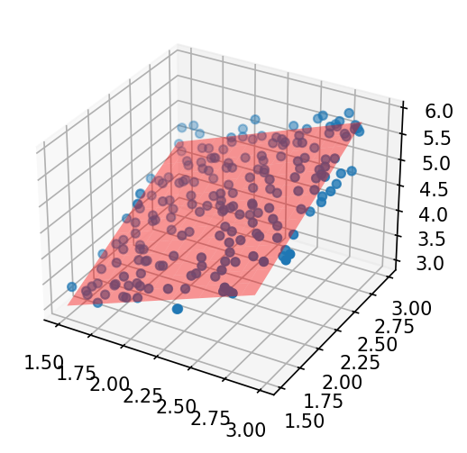

```python
# Instantiate a figure
fig = plt.figure(dpi=150)
ax = fig.gca(projection='3d')

# Plotting our data points
ax.scatter(linear_df[['x0']].to_numpy(),
           linear_df[['x1']].to_numpy(),
           linear_df['y'].to_numpy())

# Creating a mesh to draw the linear regression hyperplane
x0_surf = np.arange(linear_df[['x0']].min().values, linear_df[['x0']].max().values, 0.1)
x1_surf = np.arange(linear_df[['x1']].min().values, linear_df[['x1']].max().values, 0.1)
x0_surf, x1_surf = np.meshgrid(x0_surf, x1_surf)
exog = pd.core.frame.DataFrame({'x0': x0_surf.ravel(), 'Radio': x1_surf.ravel()})

# Prediction on the mesh
out = [pred(x, theta) for x in exog.to_numpy()]

# Plotting the hyperplane
ax.plot_surface(x0_surf,
                x1_surf,
                np.array(out).reshape(x0_surf.shape),
                rstride=1,
                cstride=1,
                color='red',
                alpha = 0.4);
```